# Final Presentation

May 04, 2022 @ 02:34 PM

## Packages Used

Tidyverse was used to manipulate data and to plot data.

```r
library(tidyverse)
```

## NFL Scores and Betting Data, nfl_stadiums

This set was found on Kaggle, and it gives extensive details on every single NFL stadium. It will be used to compare variables between several different stadiums. It was updated 3 months ago according to it’s Kaggle site.

**Variables in the Dataset:**

- `stadium_name`: The name of the stadium
- `stadium_location`: The location of the stadium
- `stadium_open`: The year the stadium opened
- `stadium_closed`: The year the stadium closed (if it had closed)
- `stadium_type`: The type of stadium (indoor, outdoor, retractable)
- `stadium_address`: The address for the stadium
- `stadium_weather_station_code`: The stadium zip code for weather data collection
- `stadium_weather_type`: The weather descriptor for stadium based on average temperature
- `stadium_capacity`: The stadium seating capacity
- `stadium_surface`: The stadium surface type (grass, turf)
- `STATION`: The stadium weather station ID for NOAA data
- `NAME`: The stadium weather station name
- `LATITUDE`: The stadium latitude
- `LONGITUDE`: The stadium longitude
- `ELEVATION`: The stadium elevation

As this box plot shows, while there are still more outdoor stadiums in the NFL, the newer stadiums tend to be indoor or retractable more often.

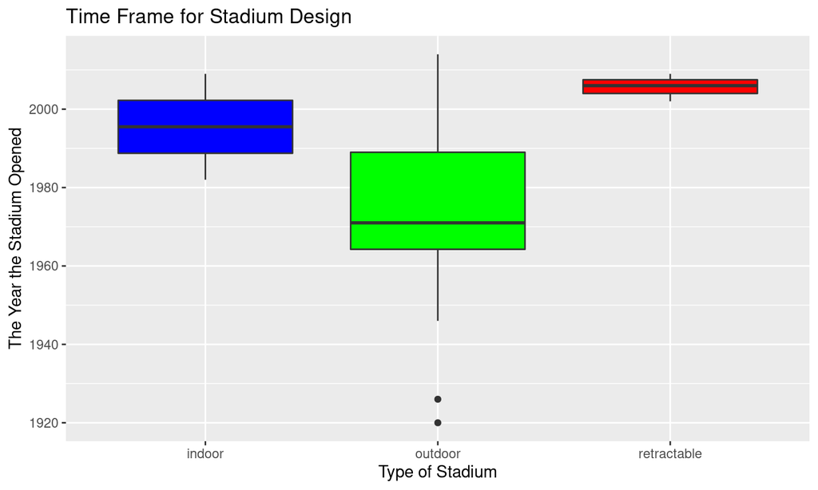

This graph shows us that stadiums in a cold location generally have higher capacity limits compared to other NFL stadiums, while dome and warm stadiums have less in general.

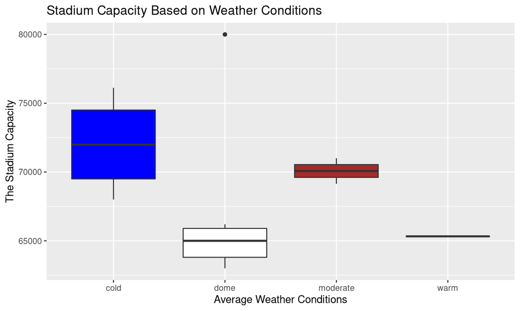